# Big Data - Homework 2

Błażej Wiórek

5/3/2020

## Power of optimal test below threshold $\sqrt{2logp}$

Recall the problem denoted as ‘needle in the haystack problem’ that refers to the situation when we have p iid random variables $X_i \sim N(\mu_i, 1)$ and the task is to test the globall null hypothesis $H_{0,i}: \mu_i = 0$, $i\in\ \{1, ..., p\}$. In the previous report Bonferroni procedure was tested when there is only one signal $\mu_i \neq 0$ and it’s strength is close (above and below) to $\sqrt{2logp}$ threshold. In this dicussion the main area of interest is answering the question: are we able to do better than Bonferroni when there is a single $\mu_i \neq 0$. The better means that we control the probability of Type I error at level $\alpha$ and increase power in the same time. This can be done via comparison to optimal test defined by Neyman-Pearson Theorem, which will be called Neyman-Pearson test for convenience.

**Neyman-Pearson Theorem:** Let $X_1, X_2, ..., X_n$ denote a random sample from a distribution that has pdf or pmf $f(x; \theta)$. Then the likelihood of $X_1, X_2, ..., X_n$ is
$$L(\theta; X)= \Pi_{i=1}^nf(x_i;\theta) \text{, for } X^T=(X_1, ..., X_n)$$

Let $\theta'$ and $\theta''$ be distinct fixed values of $\theta$ so that $\Omega = \{\theta: \theta=\theta', \theta''\}$, and let k be a positive number. Let C be a subset of the sample space such that:

$$\text{(a) } \frac{L(\theta')}{L(\theta'')} \leq k \text{ for each point } x \in C$$

$$\text{(b) } \frac{L(\theta')}{L(\theta'')} \geq k \text{ for each point } x \in C^c$$

$$\text{(c) } \alpha = \mathbb{P}_{H_0}[X \in C]$$

Then C is a best critical region of size $\alpha$ for testing the simple hypothesis $H_0: \theta=\theta'$ against the alternative simple hypothesis $H_1: \theta=\theta''$.

### Assignment 1:

Let $L(X) = \frac{1}{p}exp(X_i \mu - \frac{\mu^2}{2})$ be the statistic of the Neyman-Pearson test for the “needle in haystack” problem and $\tilde{L}(X)=\frac{1}{p}\sum_{i=1}^p (exp(X_i\mu-\frac{\mu^2}{2})1_{\{X_i < \sqrt{2logp}\}})$ be its truncated version. For each of the settings $\mu=(1 + \epsilon)\sqrt{2logp}$ with $\epsilon \in \{-0.3, -0.2, -0.1\}$ and $p \in \{5000, 50000, 500000\}$ repeat the following experiments.

**Side note**: $L(X)$ is the likelihood, because $f_0(x) = \Pi^p_{i=1} \frac{1}{\sqrt{2\pi}}{e^{-\frac{1}{2}x_i^2}}$ and $f_1(x) = \frac{1}{p}\sum^p_{i=1} \frac{1}{\sqrt{2\pi}} e^{-\frac{1}{2}(x_i^2-\mu)} \Pi^p_{i > 1} \frac{1}{\sqrt{2\pi}}{e^{-\frac{1}{2}x_i^2}}$, hence $L = \frac{f_1}{f_0}$. Without loss of generality it is assumed that $X_1 \sim (\mu, 1)$.

#### a) Estimate $P_{H_0}(L(X) \neq \tilde{L}(X))$

Due to independence of $X_i$ it’s easy to get the true probablility, because:
$$\mathbb{P}_{H_0}(L(X) \neq \tilde{L}(X)) = 1 - \mathbb{P}_{H_0}(L(X) = \tilde{L}(X)) = 1 - [\mathbb{P}(X_1 < \sqrt{2logp}]^n$$

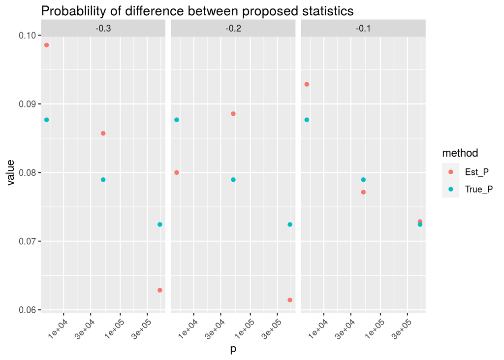

Probablility of $L(X) \neq \tilde{L}(X)$ is low and descending when $p$ grows. It can be concluded that $\sqrt{2logp}$ grows a little faster then the quantiles of $|z(\frac{\alpha}{2})|$ for $\alpha=0.05$. This result match observations from report 1 - assignment 2.

#### b) Calculate the sample mean and sample variance of $L(X)$ and $\tilde{L(X)}$

By the proposition given during the lecture if $\mu^{(p)} = (1-\epsilon)\sqrt{2logp}$, then $L \xrightarrow{\mathbb{P}} 1$.

Given proposition state that the bigger the number of hypothesis, the less variability is associated with statistic $L$. This result provides information on the expected results from the experiments b)-d).

- 2. Mean converges to 1 and variance converges to 0 as p grows.
- 3. Maximum of $L(X)$ and $\tilde{L}(X)$ should converge to 1, but care must be taken as the convergence is due to probability.
- 4. Because $L(X)$ converges to 1, the quantile will be shrunken towards 1 as well.

These conclusion are observable when we are far from threshold $\sqrt{2logp}$. The closer we get to the boundary with power of signal $\mu$, the stronger the deviations from expected behaviour. It’s interesting that truncated version of likelihood behaves better, but on the other hand the influence of every observation that may be the evidence against $H_0$ is neglected. This property is especially visible on the plot of estimated maximum of the likelihood.

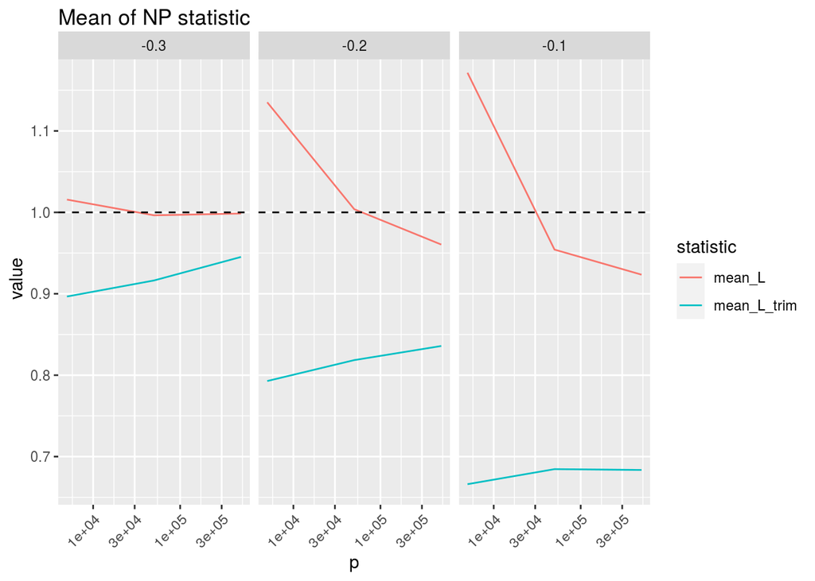

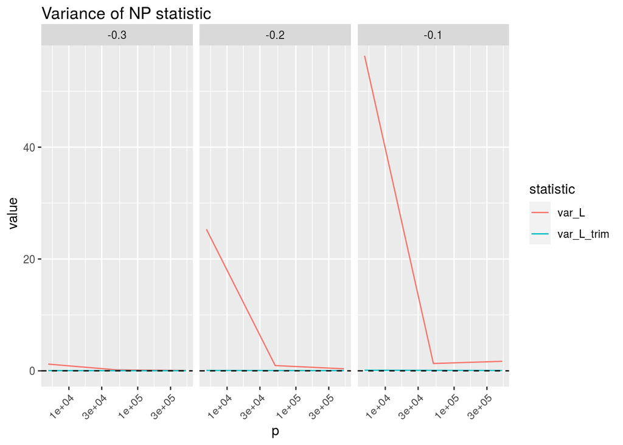

#### c) Estimate the maximum of L(X) and L’(X)

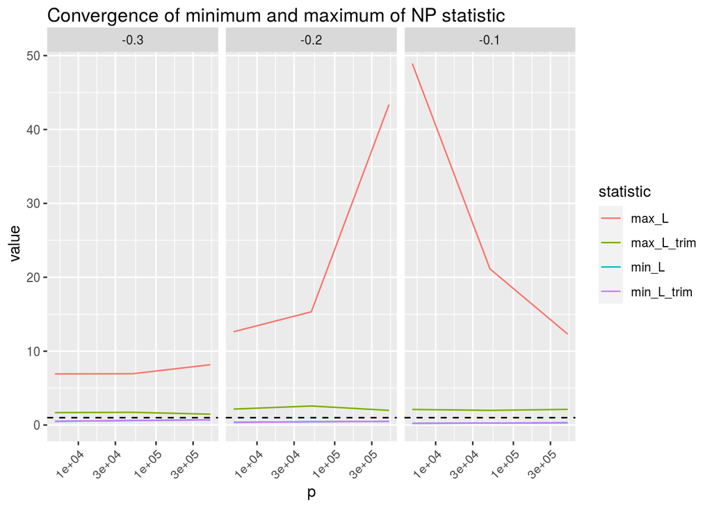

#### d) Report 0.95 quantile of L(X) and L’(X)

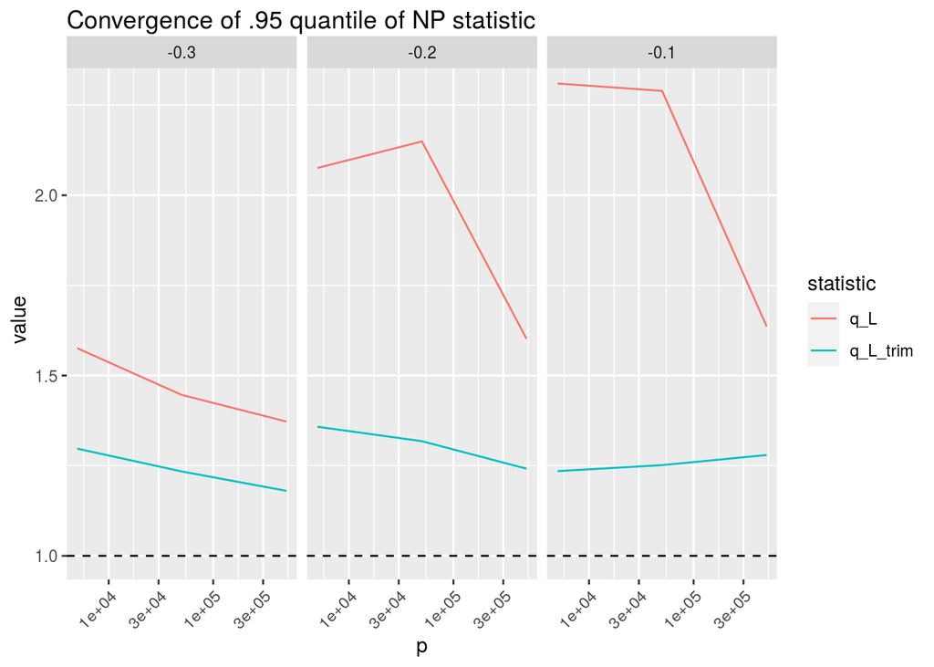

### Assignment 2

For p=5000 and p=50000 estimate the critical values of the optimal Neyman-Pearson test for the needle in the haystack problem against alternatives:

- $\mu^{(p)} = 1.2\sqrt{2logp}$
- $\mu^{(p)} = 0.8\sqrt{2logp}$

Use the significance level $\alpha=0.05$.

Critical values for the scenario where $\mu^{(p)}=0.8\sqrt{2logp}$ were already obtained in the previous assignment (when computing quantiles).

```
##    eps     p      q_L  q_L_trim
## 1 -0.2  5000 2.075653 1.3580341
## 2 -0.2 50000 2.149305 1.3178922
## 3  0.2  5000 1.820010 0.6057473
## 4  0.2 50000 1.376355 0.5272229
```

Rather obvious observation is that when strength of the signal $\mu$ decrease, then quantile of the likelihood statistic is growing, because there are many $X_i$ that are not in C (=> the likelihood is higher).

### Assignment 3

For $p=5000$ and $p=50000$ and $\alpha=0.05$ compare the power of the above Neyman-Pearson test with the power of the Bonferroni test when

- 1. $\mu_1 = 1.2\sqrt{2logp}$, $\mu_2=...=\mu_p=0$
- 2. $\mu_1=0.8\sqrt{2logp}$, $\mu_2=...=\mu_p=0$

Bonferroni procedure test each $H_{0, i}$ at level $\frac{\alpha}{n}$. If p-values associated with i-th test is $p_i$, then bonferroni rejects global null if $min_i p_i \leq \frac{\alpha}{n}$.

If the NP $\mu_1 = 1.2\sqrt{2logp}$, then we exepect that Neyman-Pearson test has full power. Let D be a critical region of size $\alpha$ associated with Bonferroni procedure. It was shown that Bonferroni procedure has full power above the threshold $\sqrt{2logp}$, hence $\mathbb{P}_{H_1}(max\{x_i\} > |z(\frac{\alpha}{n})|) \rightarrow 1$. It simply means that $\mathbb{P}_{H_1}(\text{ Type II Error }) \rightarrow 0$ and if $\gamma_C(\theta)$ is power function, then $\gamma_D(\mu) = \mathbb{P}_{H_1}(X \in C) \rightarrow 1$. By the Neyman-Pearson theorem we have that $\gamma_C(\mu) \geq \gamma_D(\mu)$, where C is critical region associated with Neuman-Pearson test. The conclusion is that we expect Neyman-Pearson to have a full power above the threshold $\sqrt{2logp}$ as well.

**Performance above threshold**:

```
##     bonferroni neyman_pearson
##           1000           1000
```

**Performance below threshold**:

```
##     bonferroni neyman_pearson
##             23             34
```

Proposition from the lecture: Set threshold $T_n(\alpha)$ such that $\mathbb{P}_0(L \geq T_n(\alpha)) = \alpha$. Then
$$\lim_{p \rightarrow \infty} \mathbb{P}(\text{Type II error}) = 1 - \alpha$$
Threshold $T_n(\alpha)$ is a quantile that was obtained in the previous experiment. If above proposition is true then by the definition $\mathbb{P}_0(L \geq T_n(\alpha)) = \mathbb{P}(\text{Type I error}) = \alpha$, thus $\mathbb{P}(\text{Type I error}) + \mathbb{P}(\text{Type II error}) \rightarrow 1$. It’s immediate that the Neyman-Pearson test has no power when $\mu < \sqrt{2logp}$.

In presented experiment it seems that Neyman-Pearson test performs better, because it has greater power. It happens because above proposition is an asymptotic result. As p grows the difference should vanish.